# Introduction to Working with Spreadsheets

Preparing, exploring and charting research data in Google Sheets

Author

NC State University Libraries — Data Science Services

Published

October 19, 2026

**ImportantHow to use this guide**

This is the page we work from in the session. Every step is written out, so you can follow along, catch up if you fall behind, and come back to it later.

- **Work in your own copy of the workbook.** Section 2 shows you how to make one.
- **Printed checklist:** the steps without the explanations, to tick off as you go. [Open the checklist](https://ncsu-libraries.github.io/intro-spreadsheets/spreadsheets-checklist.html), and print it from your browser.

# Welcome

Spreadsheets are where a lot of research data starts: survey exports, lab measurements, field sheets, downloads from a database. Before you can analyze that data you have to prepare it: understand it, fix its problems and reshape it. Today we do all of that in Google Sheets with a real dataset, the American Time Use Survey, and use it to answer one question that gets sharper as we go:

**How do people split their day between household chores and leisure?**

By the end of this session you will be able to:

1. Describe tidy, rectangular data, and say when a spreadsheet is (and isn’t) the right tool.
2. Set up a workbook that keeps raw data untouched and has a place to record your changes.
3. Use a data dictionary to rename columns, recode values and write validation rules.
4. Find and fix common data problems: inconsistent text, extra spaces, numbers stored as text, missing-value codes, out-of-range values and duplicates.
5. Write formulas that create new variables.
6. Summarize data with summary functions and pivot tables.
7. Make and customize charts that show a distribution, not just an average.

## The questions we’ll answer

|  | Question | Where |
| --- | --- | --- |
| 1 | Who is in this data, and how many? | Section 1, Section 2 |
| 2 | Can we trust these values? | Section 3 to Section 5 |
| 3 | How much of a day goes to chores, and how much to leisure? | Section 6, Section 7 |
| 4 | Does leisure time change with age? | Section 7, Section 8 |
| 5 | Do people with more children trade leisure for chores? | Section 7, Section 8 |
| 6 | People with more education report less leisure. Is that about education, or about work? | Section 7 |
| 7 | How do we show the answer? | Section 8 |

## About the data

The [American Time Use Survey](https://www.bls.gov/tus/) (ATUS) is collected every year by the U.S. Bureau of Labor Statistics. Each respondent describes one day, activity by activity, and the survey records how many minutes they spent on each kind of activity. Our workbook has a random sample of 2,000 respondents from 2003–2023, with a few demographic columns and a few activities.

Two things to keep in mind about any result we get today:

- **It describes this sample, not the US population.** ATUS supplies survey weights to make national estimates; we don’t use them.
- **Each person reports one day.** Someone who did no laundry on their diary day may do plenty on other days.

# 1 Spreadsheets for research

> **Question 1:** Who is in this data, and how many?

Researchers use spreadsheets to collect data, prepare it for analysis, take a first look at it and share it with collaborators. Spreadsheets are very good at letting you *see* your data. They are weaker at keeping a record of what you did: a click-and-drag change leaves no trace, so it’s hard to repeat or to check later. That’s why R and Python (the other two tracks today) exist, and why two habits in this session matter so much: **never edit the raw data, and write down every change.**

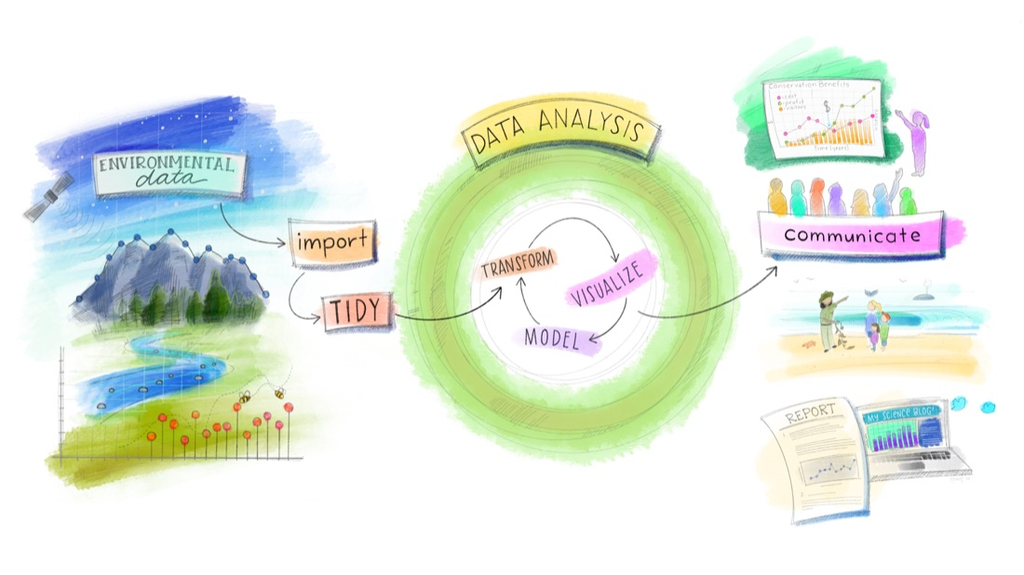

Where today’s work fits: data comes in, gets tidied, then goes round a loop of transforming, visualizing and modeling before it’s communicated. Artwork from @juliesquid for @openscapes (illustrated by @allison_horst), [CC BY 4.0](https://creativecommons.org/licenses/by/4.0/).

## 1.1 Words we’ll use

- **Workbook:** the whole file.
- **Sheet:** one tab in the workbook.
- **Cell:** one box, named by column and row (B7). A **range** is a block of cells (A2:A2001).
- **Row** and **column.** The **header** is the first row, which holds the column names.
- **Formula bar:** the bar above the sheet that shows what’s really in a cell. A cell can *show* a result, 147, while *storing* the formula that makes it, `=SUM(S2:V2)`.
- **Name box:** left of the formula bar. It shows the address of the selected cell, and you can type an address or range there to jump to it.

[figure not shown]

The parts of a Google Sheets window, in the workbook we use today.

## 1.2 Tidy data

Analysis tools, including spreadsheet features like pivot tables, expect data laid out in one way:

- Each **variable** is a column.
- Each **observation** is a row.
- Each **value** is a cell.
- Each table is its own sheet.

In our data, one row is one survey respondent, and each column is one thing we know about them.

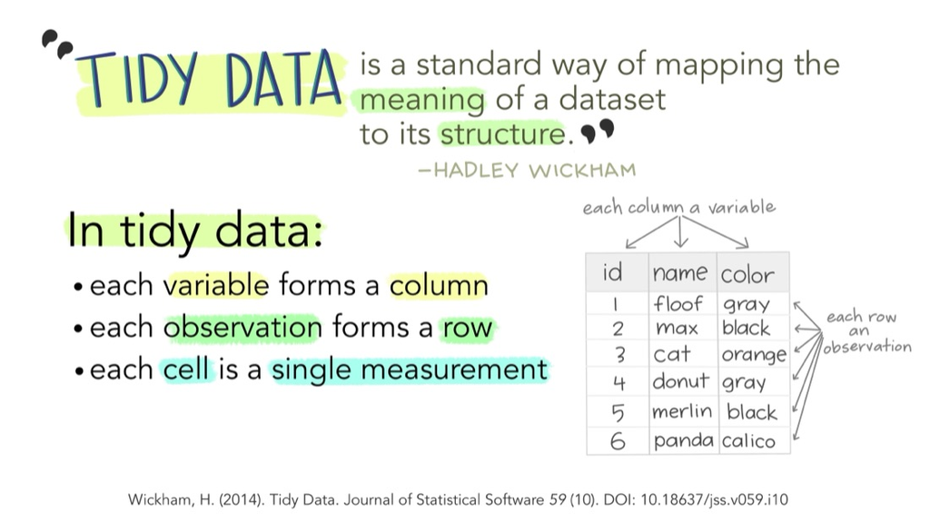

Illustration from [Tidy Data for reproducibility, efficiency, and collaboration](https://openscapes.org/blog/2020-10-12-tidy-data/) by Julia Lowndes and Allison Horst, [CC BY 4.0](https://creativecommons.org/licenses/by/4.0/).

Tidy data is worth the effort because every tidy table works with the same tools in the same way. Untidy data needs a new workaround every time.

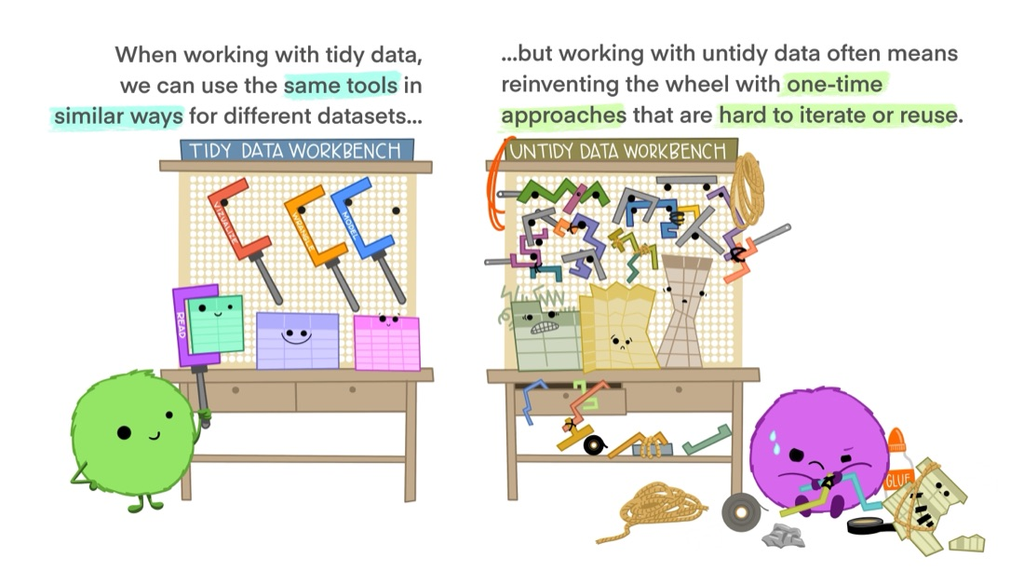

Illustration from [Tidy Data for reproducibility, efficiency, and collaboration](https://openscapes.org/blog/2020-10-12-tidy-data/) by Julia Lowndes and Allison Horst, [CC BY 4.0](https://creativecommons.org/licenses/by/4.0/).

### 1.2.1 Wide and long

The same data can be tidy in more than one shape. Say you measure the height of five plants on three days. **Wide** has one row per plant and one column per day. **Long** has one row per plant per day, with a “day” column and a “height” column. Long is what most analysis tools expect for repeated measurements, so choose the shape on purpose before you start entering data.

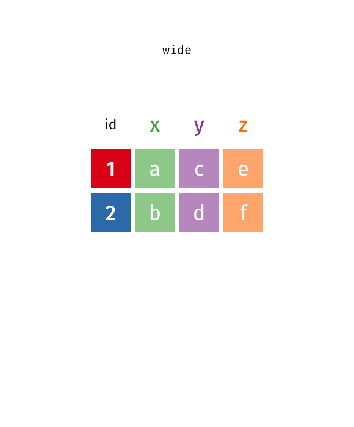

The same reshape, animated: a wide table with one row per id and columns x, y and z becomes a long table with one row per id and key, then back again. The code at the top is R’s (`pivot_longer()` and `pivot_wider()`); the idea is the same in any tool. Animation by Garrick Aden-Buie, tidyexplain, [CC0](https://creativecommons.org/publicdomain/zero/1.0/).

### 1.2.2 Common problems

These all break the “one variable, one observation, one value” rules, and they all make data harder to analyze:

- Merged cells.
- Notes typed into data cells (“about 40?”).
- **Color used as data** (yellow rows = “check these”). Color doesn’t survive saving as CSV, and formulas, filters and pivot tables can’t read it. If something matters, put it in a column.
- More than one value in a cell (“12, 15”).
- Units inside values (“40 hrs”).
- Several tables on one sheet.

[figure not shown]

Six common problems, numbered in the order of the list above.

One value per cell often means splitting a column in two:

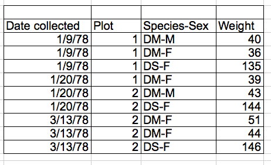

Before: species and sex in one column.

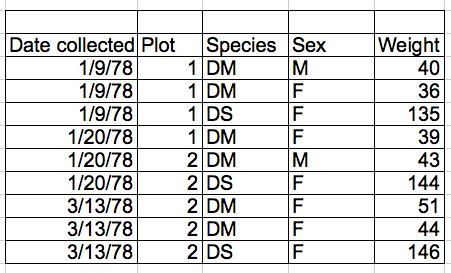

After: Species and Sex in their own columns.

From [Data Organization in Spreadsheets for Ecologists](https://datacarpentry.github.io/spreadsheet-ecology-lesson/), Data Carpentry, [CC BY 4.0](https://creativecommons.org/licenses/by/4.0/).

## 1.3 How Sheets reads what you type

When you type into a cell, Sheets decides whether it’s a number, a date or text. By default, **numbers line up on the right and text on the left.** A “number” sitting on the left is stored as text, and calculations will skip it. Glancing at alignment is the fastest first check of any column.

# 2 Set up your workbook

The workbook has four sheets, and each has one job. Keeping them separate means you can always get back to the original and see what you changed.

## 2.1 Make your copy

1. Go to go.ncsu.edu/dss-atus-working. Google Sheets asks whether you’d like to make a copy of DSTI ATUS Data Working.
2. Click **Make a copy**. Your copy opens, named “Copy of DSTI ATUS Data Working”.
3. Click the name at the top left and rename it “[Your name] DSTI spreadsheets”.

[figure not shown]

The link opens this page instead of the workbook itself, so you always get your own copy.

**WarningGotcha: the link asks you to sign in or request access**

You’re probably signed in to a personal Google account, or not signed in. Switch to your NC State account (top right of the window) and try the link again. If it still fails, download [the workbook file](https://github.com/NCSU-Libraries/intro-spreadsheets/raw/main/data/DSTI%20ATUS%20Data%20Working.xlsx), open a blank sheet, and use **File > Import > Upload**.

## 2.2 What’s in the workbook

- **README**: the data dictionary: what each column means, its allowed values, and what its codes are.
- **raw**: the data as it came from ATUS. **Never edit this sheet.**
- **working**: a copy we’ll prepare and analyze. Some of it has already been tidied, the way you might receive data from a collaborator. The rest is up to you.
- **log**: where you record each change you make: the date, the column, what changed and why. In your own work, every change goes here. Today’s data is for practice, so we won’t fill it in, but the steps say where you would.

The `working` sheet’s columns, for reference:

The `working` sheet’s columns. New columns you make go to the right, starting at W.

| Column | Header | What it is |
| --- | --- | --- |
| A | Case | Respondent ID |
| B | Diary Year | Year of the diary day |
| C | Diary Day | Day of the week of the diary day |
| D | Metropolitan | Lives in a metropolitan area? |
| E | Education level | Highest degree |
| F | Age | Age in years |
| G | Sex | Sex |
| H | TRCHILDNUM | Number of children under 18 in household |
| I | Labor force status | Employed, unemployed, or not in the labor force |
| J | Enrolled in school | Enrolled in high school, college or university. Asked only of ages 15–49; “Blank” means not asked. Not used today. |
| K | TEHRUSLT | Hours usually worked per week |
| L | Sleep (mins) | Minutes sleeping on the diary day |
| M–P | Interior cleaning, Laundry, Food and drink prep, Kitchen clean-up (mins) | Household chores |
| Q–R | Eating and Drinking, Grocery Shopping (mins) | Neither chores nor leisure |
| S–V | Reading, Playing games, TV and Movies, Socializing (mins) | Leisure |

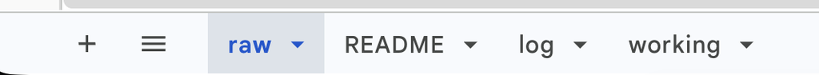

The four sheet tabs, at the bottom of the window. Click a tab to switch sheets.

## 2.3 Find your way around the data

1. Click the **working** tab.
2. **View > Freeze > 1 row.** The header now stays in view as you scroll.
3. Click any cell in column A, then press **Ctrl + ↓** (Mac: **Cmd + ↓**) to jump to the last row. The row number tells you how many respondents there are (one less than the row number, because of the header). Then scroll back up to the top.

**Selecting down to the last row.** This guide writes a range that runs from a cell to the bottom of its column like this: **W2:W** means “W2 and everything below it”. To select one:

- Click the first cell (W2), then press **Ctrl + Shift + ↓** (Mac: **Cmd + Shift + ↓**). The selection runs down to the last filled cell. This works when the column has no empty cells.
- Or type the range (`W2:W`) in the **Name box** at the top left, just left of the formula bar, and press **Enter**.

**TipExtra: protect the raw sheet**

Right-click the **raw** tab > **Protect sheet**. You can then choose who may edit it, or have Sheets warn anyone (including you) who tries. It’s a guard against the classic accident of editing the wrong sheet.

**TipExtra: version history**

**File > Version history > See version history** shows every saved version of the workbook and who changed what. You can name a version (“before preparing”) and restore it. Day 1 of the intensive covered version control in more depth.

# 3 Entering data well

> **Question 2:** Can we trust these values? (Sections 3 to 5.)

**Data preparation** is everything you do to get data from the form it arrives in to a form you can analyze: setting rules for what’s allowed, making it understandable, and finding and fixing its problems. Sections 3 to 5 are all preparation. You’ll also hear it called data cleaning, wrangling, tidying or munging, and some people use “cleaning” for just the fixing part. This guide says *preparing* for all of it.

Most data problems start at data entry. Knowing what kind of data each column holds, and telling Sheets what’s allowed, catches mistakes before they spread. The same rules also find mistakes already in the data.

## 3.1 Kinds of data

The kind of data in a column decides what rule fits it, which summaries make sense (an average education level means nothing) and which charts work. In our data, Sleep is continuous, Number of children is discrete, Labor force status is nominal and Education level is ordinal. Two kinds the pictures don’t show: **dates**, and **IDs** like Case, which are numbers you never do arithmetic on.

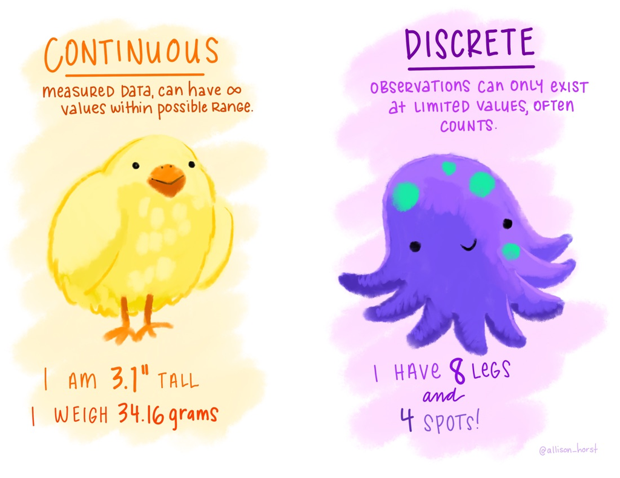

Continuous and discrete numbers.

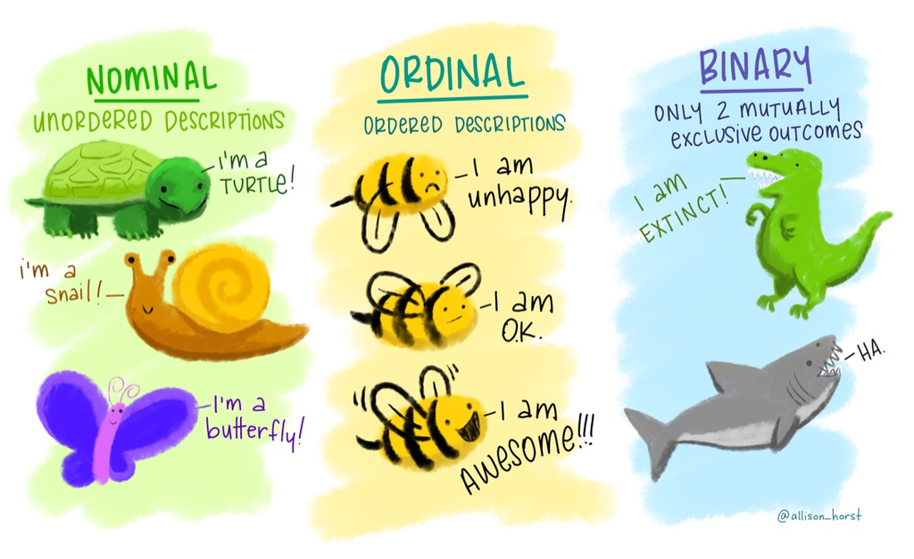

Nominal, ordinal and binary categories.

Artwork by [Allison Horst](https://github.com/allisonhorst/stats-illustrations), [CC BY 4.0](https://creativecommons.org/licenses/by/4.0/).

## 3.2 Dates

Sheets stores a date as a number: the count of days since 30 December 1899. That’s what lets you subtract one date from another. Two habits keep dates safe:

- **Type dates as YYYY-MM-DD** (2007-01-12). Sheets reads that form the same way everywhere. “01/12/2007” means 12 January in some countries and 1 December in others, and Sheets follows the spreadsheet’s locale setting (**File > Settings**).
- **Keep a date as one date column,** or as separate year, month and day columns, but decide on purpose.

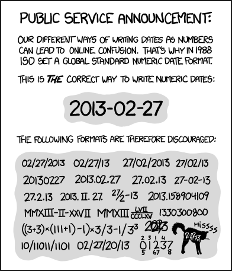

xkcd 1179, “ISO 8601”, by [Randall Munroe](https://xkcd.com/1179/), [CC BY-NC 2.5](https://creativecommons.org/licenses/by-nc/2.5/).

Try it: in an empty cell on a new sheet, type `2007-01-12`, then use **Format > Number > Number**. You’ll see 39,094.00: the day count, with the comma and two decimal places the Number format adds. Undo with **Ctrl/Cmd + Z**.

## 3.3 Validation rules from the data dictionary

**Data validation** tells Sheets what a column is allowed to hold. With a rule in place, a new entry that breaks it is flagged or refused. A rule applied to data you already have flags every cell that breaks it, which turns the data dictionary into a checklist.

1. On **README**, look up the allowed values for Sex and the allowed range for Age.
2. On **working**, select **G2:G** (all of Sex below the header: click G2, then **Ctrl/Cmd + Shift + ↓**).
3. **Data > Data validation > Add rule.**
4. Criteria: **Dropdown**. Sheets fills in every value it finds in the column. Delete all but the two allowed labels from the README, `Female` and `Male`.
5. Open **Advanced options** and choose **Show a warning**. Click **Done**.
6. Add one more rule the same way: select **F2:F** (Age), criteria **Is between** 15 and 85.

The same kind of rule works for any range in the README, such as 0 to 1440 for minutes in a day. Two rules are enough to see how it works.

Cells that break a rule now show a small red triangle in the corner. Hover over one to see why. Leave them for now: they’re the to-do list for Section 5.

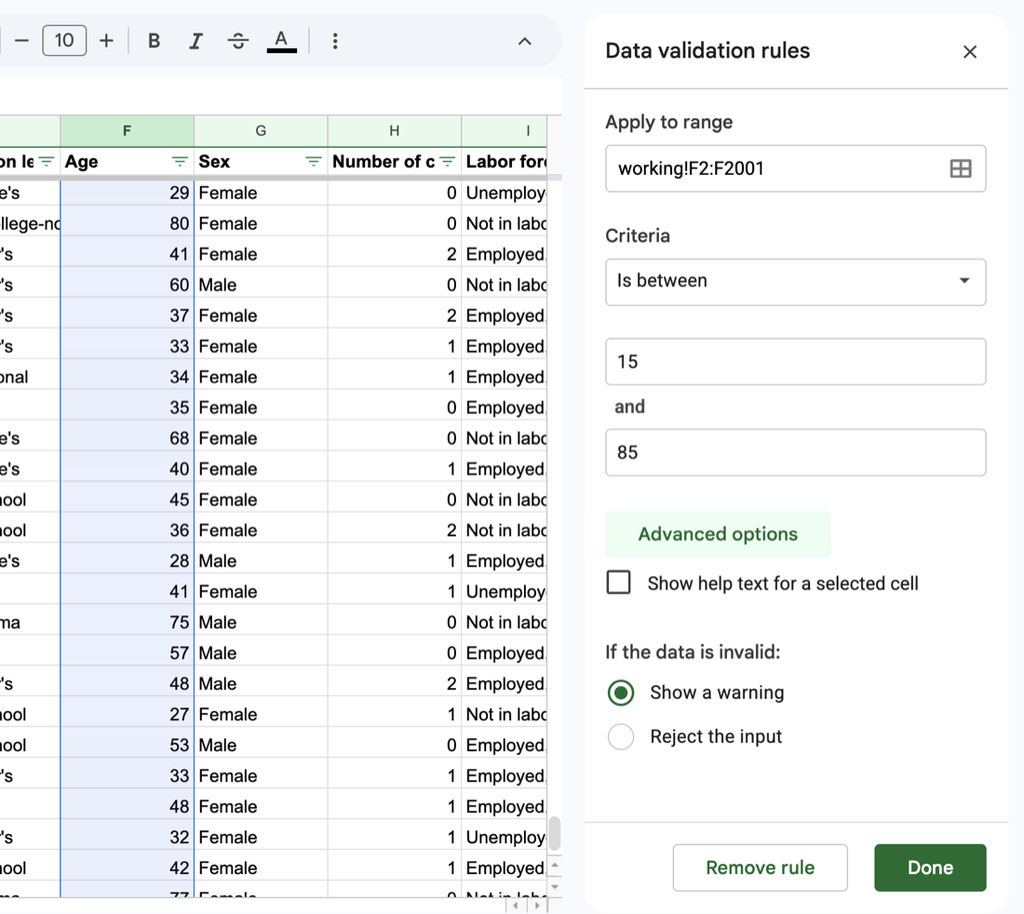

The Age rule in the Data validation sidebar, with Advanced options open.

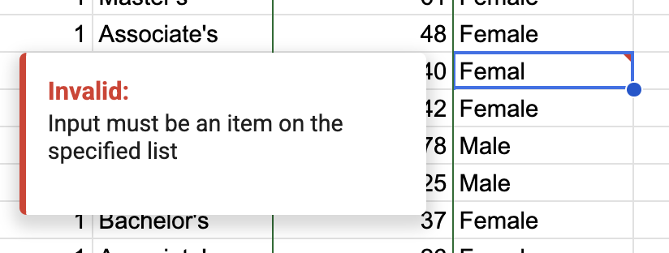

Hovering over a flagged cell. The small red triangle is in its top right corner.

**WarningGotcha: “Show a warning” or “Reject the input”?**

**Reject the input** stops anyone typing a bad value, which is what you want on a data entry form. On existing data, use **Show a warning**: it flags problems without changing anything, so you decide how to fix each one.

**WarningGotcha: dropdown chips change how the column looks**

A dropdown rule shows each cell as a colored chip. That’s display only; the value is unchanged. To switch it off, choose **Advanced options > Display style: Plain text** in the rule.

**TipExtra: tables**

**Format > Convert to table** turns a range into a Sheets table, where each column has a type (number, text, date, dropdown) and new rows follow it. It’s a quick way to set up a data entry sheet.

# 4 Making data understandable

Before you can fix data, you have to know what it means. That starts with the data dictionary, and with column names and values that a person can read.

## 4.1 Read the data dictionary

Open **README** and read the row for each column: what it measures, its type, and what each code means. Then compare it with the data. A dictionary that doesn’t match its data is common, and it’s worth catching early.

## 4.2 Rename columns

Good column names are short, consistent and include units: “Sleep (mins)”, not “T010101” or “How long did you spend sleeping”. Two headers in `working` still have their ATUS codes.

If your data is headed for R or Python, names without spaces or brackets are easier to type there. Pick one style and use it for every column.

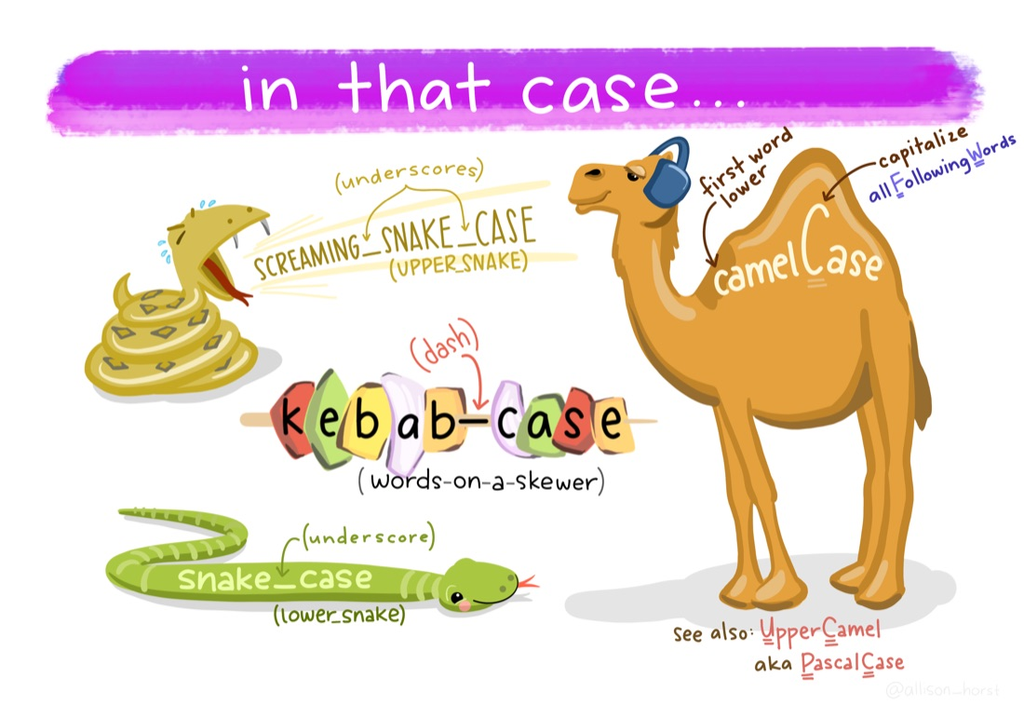

Artwork by [Allison Horst](https://github.com/allisonhorst/stats-illustrations), [CC BY 4.0](https://creativecommons.org/licenses/by/4.0/).

1. Click cell **H1** and type `Number of children`.
2. Click cell **K1** and type `Work hours per week`. *In your own work, you’d log both renames.*

## 4.3 Codes or labels?

Surveys usually store categories as numbers: 1 = Metropolitan, 2 = Non-metropolitan. Labels are easier to read, and charts and pivot tables need them. Codes have their uses too:

- **Codes keep order.** Sorted as text, the days of the week come out Friday, Monday, Saturday… The codes 1–7 sort in the right order.
- **Some analysis software expects codes.**

One way to get both is to keep a coded column next to each labeled one. We don’t do that today: it would double the number of columns, and the **raw** sheet already keeps the codes. In `working`, most columns already have labels. Metropolitan (column D) is still coded, so we’ll recode it.

## 4.4 Recode with Find and replace

The README gives Metropolitan’s codes: 1 = Metropolitan, 2 = Non-metropolitan, 3 = Not identified, -1 = blank (missing).

1. Click the column letter **D** to select the whole column.
2. **Edit > Find and replace** (Windows: **Ctrl + H**; Mac: **Cmd + Shift + H**).
3. **Find:** `-1`. **Replace with:** leave empty.
4. **Search:** **Specific range**, and check it says `working!D:D`.
5. Check **Match entire cell contents**.
6. **Replace all.** The dialog says how many cells changed.
7. Repeat for `1` → `Metropolitan`, `2` → `Non-metropolitan` and `3` → `Not identified`. *In your own work, you’d log the recode.*

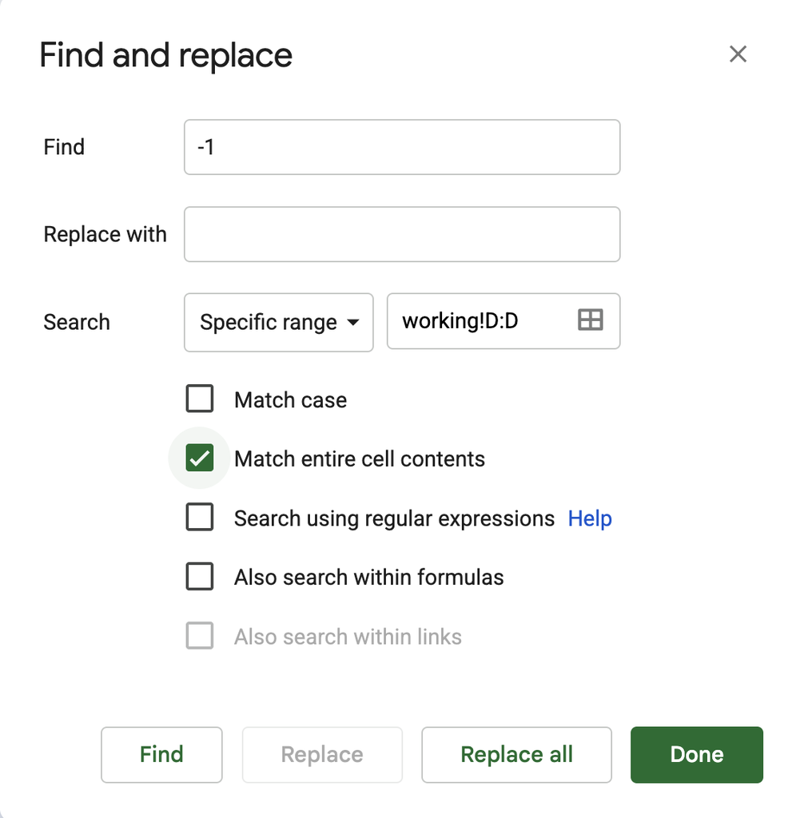

Find and replace, set up for the first recode: `-1` replaced with nothing in column D only.

**WarningGotcha: why -1 goes first, and why “Match entire cell contents” matters**

Without **Match entire cell contents**, Find and replace changes text *inside* cells. Replacing `1` would also change the 1 inside `-1`, giving “-Metropolitan”. Doing `-1` first, with the box checked, avoids both problems. The same mistake turns “Female” into “FeMale” if you replace “male”, or “Non-metropolitan” into “Non-Metro” if you shorten “Metropolitan”.

**TipExtra: recode with a lookup table**

Recoding 16 education codes with Find and replace would take 16 passes. A lookup table does it in one formula. See Extra activities.

**Checkpoint (break).** You should have: your own copy, the header frozen, H and K renamed, Metropolitan recoded, and red validation triangles still showing.

# 5 Making data usable

> **Question 2, continued:** Can we trust these values?

This is where most of the time in a real project goes. Each problem below is either flagged by a validation rule from Section 3 or easy to find with a filter. For each one, ask three things: **what’s wrong, what’s the right fix, and how do I record it?**

## 5.1 Filter, and filter views

A filter hides rows that don’t match what you choose, so you can look at one group or one problem at a time. Its list of values is also the quickest way to spot typos and inconsistent spellings.

1. Click any cell in the data, then **Ctrl/Cmd + A** to select it all. **Data > Create a filter.** Each header gets a filter button.
2. Click the filter button on **Sex**. The list shows every distinct value in the column.
3. Choose **Filter by values** to tick the values you want, or **Filter by condition** for rules like “greater than 85”. **Cancel** closes the list without filtering.

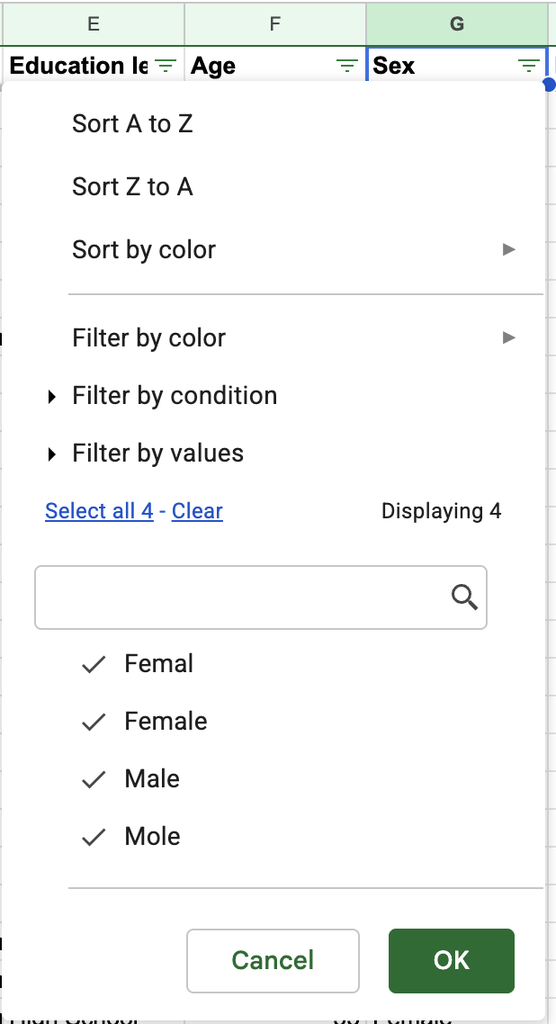

The Sex filter’s list of values: two typos sit alongside Female and Male.

**WarningGotcha: a filter changes the view for everyone**

In a shared workbook, a filter hides rows for every collaborator. A **filter view** (**Data > Create filter view**) is yours alone, and you can save it and come back to it. Use filter views when you share.

**WarningGotcha: never sort one column on its own**

Selecting one column and using **Data > Sort range** reorders that column only, so every value moves to the wrong person. Sort whole rows instead: the filter button (**Sort A → Z**), or the column letter’s menu (**Sort sheet A to Z**).

## 5.2 Fix inconsistent text

Sex should have two values, but its filter list shows four: Female, Femal, Male and Mole. In a pivot table, R or Python, each version counts as a group of its own.

**Typos** (“Femal”, “Mole”): use Find and replace, as in Section 4.

1. Select column **G**. **Edit > Find and replace.**
2. **Find:** `Femal`. **Replace with:** `Female`. **Search:** **Specific range** (column G). Check **Match entire cell contents.** **Replace all.**
3. Repeat for `Mole` → `Male`.
4. Open the Sex filter again: it lists only Female and Male.

**WarningGotcha: “Femal” is inside “Female”**

Without **Match entire cell contents**, replacing “Femal” with “Female” also changes every correct “Female” into “Femalee”. Check the box every time you recode.

**Capitalization** (“female”, “MALE”): a few cells have these, but the filter list doesn’t show them. It ignores case, so “female” is listed under “Female”. Pivot tables and `COUNTIF` ignore case too. The one place they show is the validation rule from Section 3: it does check case, so these cells still have red triangles. R and Python don’t ignore case: there, “female” and “Female” become two groups as soon as the data leaves Sheets. Fix it with a formula in a helper column, then put the results back.

1. In **W1** type `helper`. In **W2** type `=PROPER(G2)`.
2. Fill down: double-click the **fill handle**, the small blue circle at the bottom right of the selected cell. Sheets copies the formula down to the last row of the data.
3. Select **W2:W** (click W2, then **Ctrl/Cmd + Shift + ↓**), copy, click **G2**, then **Edit > Paste special > Values only** (**Ctrl/Cmd + Shift + V**). Start at row 2 so the header isn’t overwritten.
4. Clear column W. *In your own work, you’d log the fix.*

`UPPER()` and `LOWER()` work the same way. Pick one convention per column and stick to it.

**WarningGotcha: why paste values only?**

Column W contains formulas that point at G. If you pasted the formulas into G, they’d point at the wrong cells and break. Pasting **values only** keeps the results and drops the formulas.

**WarningGotcha: `PROPER()` and apostrophes**

`PROPER()` capitalizes the first letter after any character that isn’t a letter, so “master’s” becomes “Master’S”. That’s why we use it on Sex and not on Education level.

## 5.3 Remove extra spaces and spelling variants

Open the filter on **Education level**. Some levels are listed more than once, in near-identical versions: ” Bachelor’s” with a space in front, “Master’s” with one after, and “Bachelors” and “Masters” without the apostrophe. A space before or after a value is invisible, but ” Bachelor’s” and “Bachelor’s” are different values.

[figure not shown]

The idea behind Trim whitespace and `TRIM()`. The title is an R function that does the same job. Artwork by [Allison Horst](https://github.com/allisonhorst/stats-illustrations), [CC BY 4.0](https://creativecommons.org/licenses/by/4.0/).

Trim whitespace removes the spaces in place. `=TRIM()` does the same in a helper column, if you want to keep the original.

1. Click any cell in the data, then **Ctrl/Cmd + A** to select it all. **Data > Data cleanup > Trim whitespace.** Sheets reports how many cells it trimmed (9). Click **OK**.
2. Select column **E**. Find and replace, with **Match entire cell contents** checked: `Bachelors` → `Bachelor's` and `Masters` → `Master's`.
3. Open the Education level filter again: each level is listed once. *In your own work, you’d log both fixes.*

## 5.4 Fix numbers stored as text

Look at columns **O** (food and drink prep) and **Q** (eating and drinking). A few values sit on the left: they’re text, so sums and averages skip them. Two have quotation marks around them (`"300"`), and two have a unit typed in (`0min`, `120 min`), one of the common problems from Section 1.

1. Select **O2:Q** (start at row 2). **Edit > Find and replace**, **Search: Specific range**.
2. Find `"` and replace with nothing. **Replace all.**
3. Find `min` (with a space before it) and replace with nothing. **Replace all.** Then do the same for `min` without the space.
4. **Format > Number > Number.** The values move to the right: they’re numbers now.
5. The Number format shows two decimal places (300.00). With O2:Q still selected, click **Decrease decimal places** (**.0←** in the toolbar) twice to show whole minutes again.

**WarningGotcha: leave the header out of the range**

The headers in these columns end in “(mins)”. Replacing `min` in the whole column would turn “Food and drink prep (mins)” into “Food and drink prep (s)”. Starting the range at row 2 keeps the header safe.

## 5.5 Missing values: why and how

There’s more than one kind of “missing”, and they mean different things. Look at **Work hours per week** (column K) and the README:

- **Empty cell:** no value recorded. Column K has none, but you’ll meet them in most data.
- **-1:** not asked. ATUS labels it “Blank” (see the README). It asks about work hours only of people who are employed, so -1 means the person isn’t employed.
- **-4:** hours vary.
- **0:** a real zero.

To see why it matters, put these in two empty cells on a new sheet:

- `=AVERAGE(working!K2:K)`
- `=AVERAGEIF(working!K2:K, ">=0")`

The first treats -1 and -4 as numbers of hours and drags the average down: about 23 hours, against about 40 for the people who reported their hours.

What to do with codes like these:

- **Keep the code, and flag it** in a column, so every analysis can include or exclude it on purpose. That’s what we’ll do.
- **Make it empty,** if no one will need the reason.
- **Fill in a value** (such as 0) only if that value is true. Replacing -1 with 0 would claim that people who aren’t working work zero hours, which is close, but say so if you do it.
1. In **W1** type `Work hours missing`. In **W2** type `=OR(K2=-1, K2=-4)`.
2. Fill down. Each row now says TRUE or FALSE, a flag you can filter and count. *In your own work, you’d log this decision and why.*

**WarningGotcha: a flag goes in a column, not in a color**

Highlighting the -1 cells yellow would look helpful but can’t be filtered, counted, or saved to CSV. The TRUE/FALSE column can.

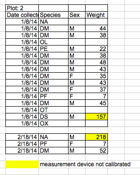

Before: yellow means “not calibrated”, explained in a note below the data.

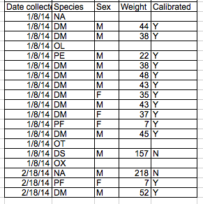

After: the same information in a Calibrated column.

From [Data Organization in Spreadsheets for Ecologists](https://datacarpentry.github.io/spreadsheet-ecology-lesson/), Data Carpentry, [CC BY 4.0](https://creativecommons.org/licenses/by/4.0/).

## 5.6 Values out of range: QA/QC

The red triangles on Age (from Section 3) mark values outside the allowed range. For a quick overview of any column, select it and use **Data > Column stats**, which shows how the values are spread and which are most common.

One example shows the whole process. For a flagged value, decide whether it’s an error, a code, or real:

- **Age 150:** impossible: an entry error. The **raw** sheet is the source here.
- **Age 80 and 85:** real, but not exact. ATUS *top-codes* age: everyone 80–84 is recorded as 80, and 85 or older as 85. Check the documentation before you “fix” a value that looks odd.

What to do with a confirmed error: correct it from the source if you can; otherwise make the cell empty and log it. Don’t delete the whole row without recording why.

1. Click the filter button on **Age** > **Filter by condition** > **Greater than**, type `85`, and click **OK**. Only the row with 150 is left.
2. Note its Case in column A. On **raw**, press **Ctrl/Cmd + F** and search for that Case: the age there is 33.
3. Back on **working**, type `33` in the Age cell. *In your own work, you’d log the correction.*
4. Clear the filter: Age’s filter button > **Filter by condition** > **None** > **OK**.

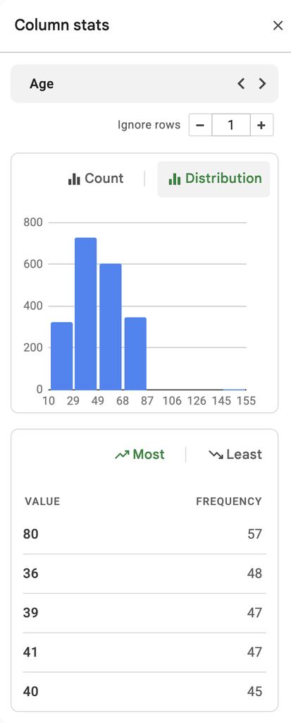

Column stats for Age. The axis runs out to 155 because of one impossible value, and the most common age is 80, the top-coded 80–84 group.

## 5.7 Duplicates

What counts as a duplicate depends on the data:

- **Exact duplicate rows:** usually an entry or copy-and-paste error. Safe to remove.
- **Same ID, different values:** which row is right? Check the source; don’t guess.
- **Legitimate repeats:** repeated measurements of the same person aren’t duplicates at all. Aggregate them if you need one row per person.

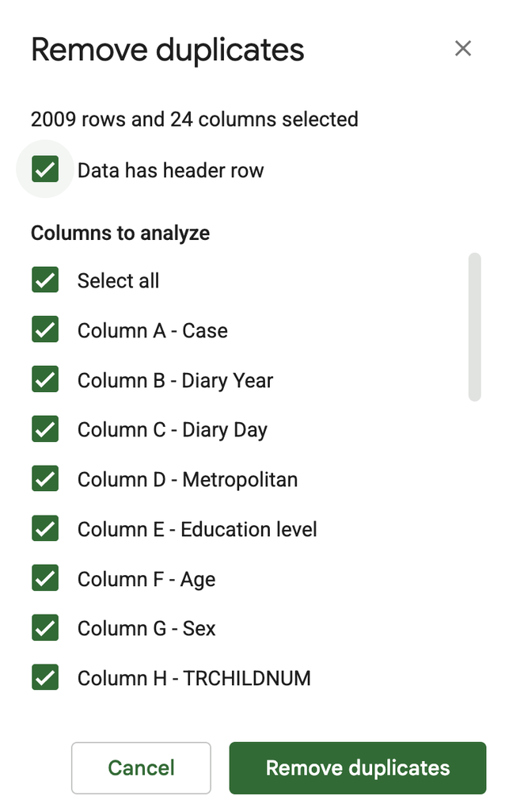

Remove duplicates with Data has header row ticked and every column selected, so only exact duplicate rows go.

**Checkpoint.** The `working` sheet is now ready to analyze.

# 6 Making new variables with formulas

> **Question 3:** How much of a day goes to chores, and how much to leisure?

The questions we want to answer need columns the data doesn’t have yet: total chores, total leisure, and groups like age group and work status. Formulas build them from the columns we have.

## 6.1 Anatomy of a formula

- A formula starts with `=`.
- It refers to cells by address (`M2`) instead of typing in their values, so the result updates when the data changes.
- It can use operators: `+ - * / ^` (add, subtract, multiply, divide, power).
- It can use functions: `SUM(M2:P2)` adds a range.
- Click a cell to see its formula in the formula bar.

When you fill a formula down, its references move with it: `M2` in row 2 becomes `M3` in row 3. That’s a **relative** reference. A **`$`** stops it moving: `$B$1` always points at B1. That’s an **absolute** reference, and you’ll need it whenever every row should use the same cell.

**WarningGotcha: pasting a formula’s text isn’t filling it down**

If you paste a formula’s text into several cells at once, every cell gets exactly the same references. Enter the formula in the first cell, then fill down (double-click the fill handle, or select the range and press **Ctrl/Cmd + D**). Sheets only adjusts references when it fills.

## 6.2 Totals: arithmetic across columns

What counts as “chores” and “leisure” is a research decision, so it’s written on the README:

- **Chores:** interior cleaning, laundry, food and drink prep, kitchen clean-up (M to P).
- **Leisure:** reading, playing games, TV and movies, socializing (S to V).
- Eating and drinking, and grocery shopping, count as neither.
1. **X1:** `Chores (mins)`. **X2:** `=SUM(M2:P2)`.
2. **Y1:** `Leisure (mins)`. **Y2:** `=SUM(S2:V2)`.
3. Select X2:Y2 and fill down.

Check one row by hand to make sure the formula covers the right columns.

## 6.3 Groups from numbers

Pivot tables and charts compare groups, so we turn numbers into categories.

**Age group,** for question 4:

1. **Z1:** `Age group`. **Z2:**

   ```
   =IFS(F2<25, "15-24", F2<35, "25-34", F2<45, "35-44", F2<55, "45-54", F2<65, "55-64", TRUE, "65+")
   ```

2. Fill down.

`IFS` checks each condition in order and returns the label for the first one that’s true. `TRUE` at the end catches everything left.

**Children group,** for question 5. Try this one yourself:

1. **AA1:** `Children group`. Make a formula that gives “0”, “1”, “2” or “3+” from column H.

   Answer: `=IF(H2>=3, "3+", TO_TEXT(H2))`

**Work status,** for question 6. The full-time cut-off goes in its own cell, so it’s written down and easy to change, instead of being buried in every formula:

1. Add a sheet named **settings**. In **A1** type `Full time from (hours)`, and in **B1** type `35`.
2. On **working**, **AB1:** `Work status`. **AB2:**

   ```
   =IFS(K2=-1, "Not working", K2=-4, "Hours vary", K2>=settings!$B$1, "Full time", K2>=0, "Part time")
   ```

3. Fill down.

**WarningGotcha: order and boundaries**

`IFS` stops at the first true condition. If “Part time” (`K2>=0`) came before the missing codes, -1 would never be checked. And decide where boundaries go: is 35 hours full time (`>=`) or part time (`>`)? In your own work, write the decision in the log.

**TipExtra: group the education levels**

Eight education levels make small groups at the top. Try grouping them into five (no diploma, high school, some college or associate’s, bachelor’s, graduate or professional) with `IFS`.

# 7 Exploring: summaries and pivot tables

> **Question 3:** How much of a day goes to chores, and how much to leisure?

> **Question 4:** Does leisure time change with age?

> **Question 5:** Do people with more children trade leisure for chores?

> **Question 6:** People with more education report less leisure. Is that about education, or about work?

## 7.1 Where summaries go

Put summaries on their own sheet, never under or beside the data. Otherwise filters, sorts and pivot tables pick them up as if they were respondents. Add a sheet named **summary**.

## 7.2 Built-in summaries

Select column **Y** (Leisure). The bottom right of the window shows the sum; click it to switch to average, count, minimum or maximum. **Data > Column stats** gives more, including a distribution chart.

## 7.3 Summary functions

On **summary**, try:

| Formula | What it gives |
| --- | --- |
| `=COUNTA(working!A2:A)` | Number of respondents |
| `=AVERAGE(working!X2:X)` | Average chores (mins) |
| `=MEDIAN(working!X2:X)` | Median chores (mins) |
| `=MIN(working!Y2:Y)` and `=MAX(working!Y2:Y)` | Range of leisure |
| `=STDEV(working!Y2:Y)` | Spread of leisure |
| `=COUNTIF(working!X2:X, 0)` | People with no chores on their diary day |
| `=AVERAGE(working!Y2:Y)/60` | Average leisure in hours |

Compare the average and the median for chores: about 74 vs. 30 minutes. When many people report 0 and a few report a lot, the average gets pulled up. The median is the middle person, so it’s often the better summary for minutes. That answers question 3.

## 7.4 Pivot tables

A pivot table summarizes the data by group: counts, sums, averages, and more, without writing a formula for each group.

1. Click any cell in **working**. **Insert > Pivot table**, **New sheet**, **Create**.
2. **Rows: Add > Age group.** **Values: Add > Case**, summarized by **COUNTA**. That’s how many people are in each age group.
3. **Values: Add > Leisure (mins)**, summarized by **AVERAGE**. Question 4: does leisure change with age? Yes: average leisure is lowest at 25–34 (about 190 minutes) and highest at 65+ (about 360).

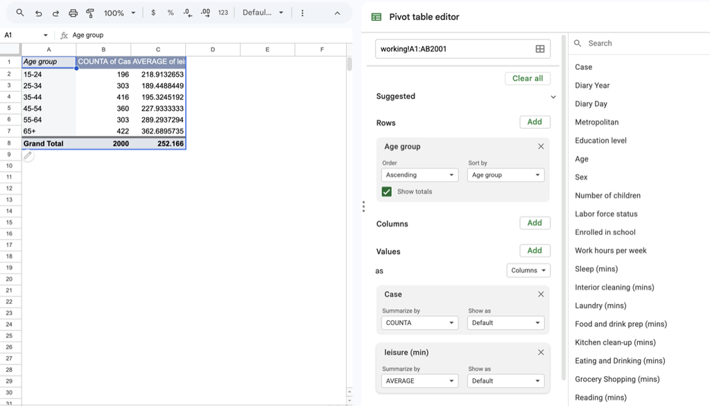

The first pivot table and its editor.

Keep the count next to the average. An average of 5 people is much less certain than an average of 500.

**Question 5:** make a second pivot table with **Rows: Children group** and **Values:** average **Chores (mins)** and average **Leisure (mins)**, side by side. From no children to 3+, chores rise from about 66 to 117 minutes and leisure falls from about 298 to 174.

**Question 6:** people with more education report less leisure. Is that education, or work?

1. Make a third pivot table. **Rows: Add > Education level.** **Values: Add > Leisure (mins)**, summarized by **AVERAGE**. The gap: about 305 minutes for no diploma, against 177 to 193 for professional and master’s degrees.
2. Add **Columns: Work status.** Now each education level is split by whether people work.
3. Compare the **Full time** column across education levels. The steady drop is gone: full-time workers at every level report roughly 170 to 235 minutes, with no pattern by degree.

Much of the education difference comes from who is working: 64% of people with no diploma have work hours of -1 (not working), against about 26–29% with a bachelor’s or master’s. The answer depends on a decision from Section 5: reading -1 as “not working”, rather than dropping it or treating it as 0. **How you prepare data changes your conclusions,** which is why, in your own work, every decision goes in the log.

**WarningGotcha: a pivot table only sees its range**

A pivot table summarizes the range it was built on. Rows added below that range are left out. Building it from whole columns (`working!A1:AB`) avoids this.

**TipExtra: more pivot table options**

- **Filters: Add > Work status,** and untick “Hours vary”. The answer barely changes; checking that is good practice.
- **See who’s working:** in the question 6 pivot table, change the value to **Case**, summarized by **COUNTA**, with **Show as: % of row**. The **Not working** column gives the 64% and 26–29% above.
- To edit a pivot table’s numbers or re-sort freely, copy it and **paste values only** somewhere else.

# 8 Visualizing averages and distributions

> **Question 7:** How do we show the answer?

We start with the chart most people make first: group averages, straight from a pivot table. Then we look at what those averages hide.

**Fell behind?** Make a copy of the finished workbook, with everything up to this point done: go.ncsu.edu/dss-atus-final. Click **Make a copy**, as in Section 2.

## 8.1 A chart from a pivot table: group averages

The question 5 pivot table from Section 7 already has the numbers: average chores and average leisure for each children group. A column chart puts them side by side.

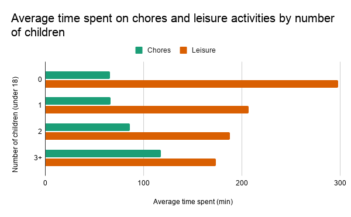

Average chores and leisure by number of children, charted from the question 5 pivot table.

**TipExtra: make it clearer**

The DSS data visualization workshops cover making a chart like this clear and accessible: sorting, labels, color and contrast. See go.ncsu.edu/datavizworkshops.

## 8.2 What an average hides

Each bar is one number standing in for hundreds of people. The interesting part is often the **distribution**: how spread out people are, and who sits far from the rest. The next two charts show it.

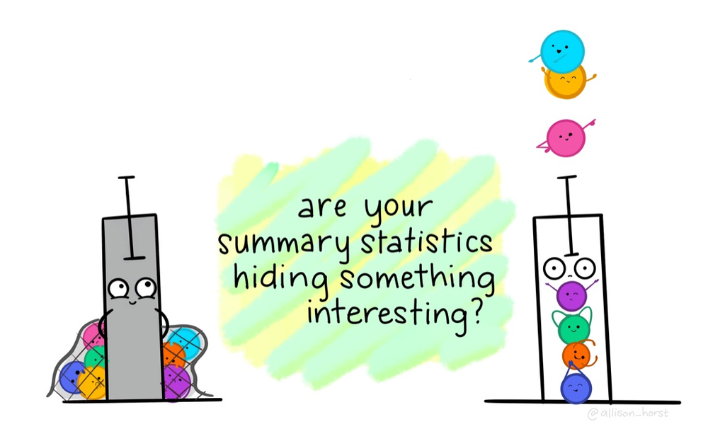

Artwork by [Allison Horst](https://github.com/allisonhorst/stats-illustrations), [CC BY 4.0](https://creativecommons.org/licenses/by/4.0/).

## 8.3 Scatter with a trendline: age and leisure

1. On **working**, click the column letter **F** (Age). Hold **Ctrl** (Mac: **Cmd**) and click **Y** (Leisure).
2. **Insert > Chart.** In the chart editor, **Setup > Chart type: Scatter chart.** Check that Age is on the X-axis.
3. **Customize > Series:**
   - **Point size:** 2px.
   - **Format > Color:** one color for all the points. Then **Fill opacity:** about 30%, so crowded areas look darker. Set the color first: changing it puts the opacity back to 100%.
   - Tick **Trendline**. Type: **Polynomial**, degree **2**. Label: **Use equation**. Tick **Show R²**.
   - **Line color** (in the trendline options): black or dark gray, so it stands out from the points.
4. **Customize > Chart & axis titles:** title “Leisure time by age”, horizontal axis “Age (years)”, vertical axis “Leisure on diary day (minutes)”.
5. **Customize > Vertical axis:** max **1440**.
6. Click the chart’s **⋮** menu (top right) > **Alt text**, and describe what it shows.

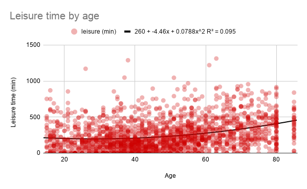

The finished scatter, with the trendline’s equation and R² in the legend.

What to notice:

- The curve (the average) is flat until about 40, then rises.
- People vary enormously around it: R² is about 0.1, so age accounts for only about a tenth of the variation in leisure.
- The dense columns at 80 and 85 are the top-coded ages from Section 5.

**WarningGotcha: a trendline describes, it doesn’t test**

A trendline summarizes the pattern in this data. It isn’t a statistical test or a model. Raising the polynomial degree always raises R², but that’s fitting noise, not finding a better answer. For tests and models, see the R and Python tracks or Get Data Help.

**WarningGotcha: “+ -” in the equation**

The equation label reads like “260 + -4.46x + …”. It’s correct, just awkward. For a figure in a paper, turn the label off and put the equation in the caption.

## 8.4 Comparing two groups’ distributions: a grouped histogram

Question 5 again: do people with 3+ children have less leisure than people with none? Averages say yes. A histogram shows *how* their days differ.

Sheets builds this one as a column chart from a pivot table. Because each bar is a range of minutes (a bin) and not a category, it works as a histogram: one bar per group in each bin.

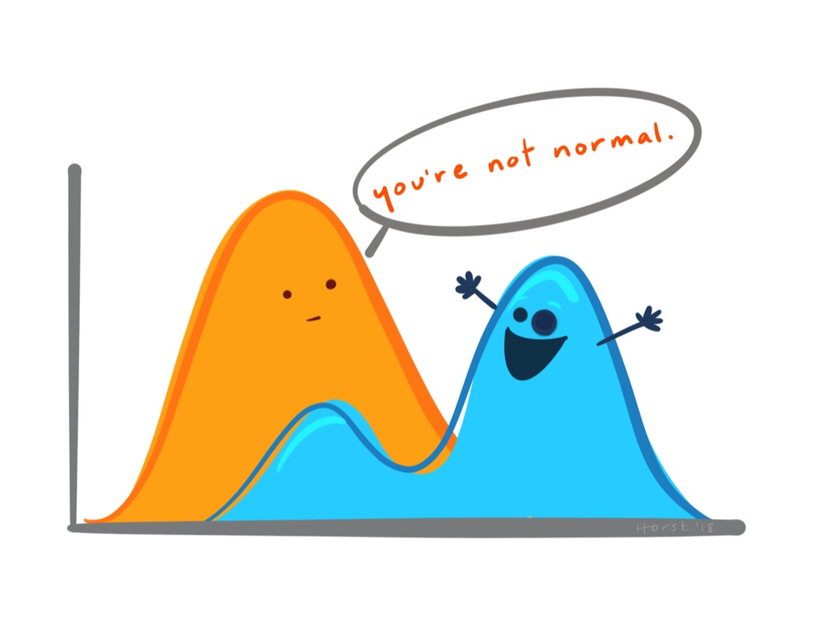

Artwork by [Allison Horst](https://github.com/allisonhorst/stats-illustrations), [CC BY 4.0](https://creativecommons.org/licenses/by/4.0/).

1. **Insert > Pivot table** from **working**, on a new sheet.
2. **Rows: Add > Leisure (mins).** Right-click any value in the pivot’s first column > **Create pivot group rule.** Interval size: **120** (two-hour bins). Click **OK**.
3. **Columns: Add > Children group.** Then **Filters: Add > Children group**, and under **Status** keep only **0** and **3+**.
4. **Values: Add > Case**, summarized by **COUNTA**. Then **Show as: % of column.**
5. Untick **Show totals** under **Rows** and under **Columns**. Otherwise the chart gets an extra bin and a third bar in each bin for the Grand Total.
6. Click any cell in the pivot table. **Insert > Chart.** If Sheets picks another type, choose **Setup > Chart type: Column chart.** Each bin has two bars, one per group.
7. **Customize > Series.** In the dropdown at the top (it starts on **Apply to all series**), choose each group in turn and give it a **Color**: a dark and a light shade of one color. The groups have an order (no children, then 3+), and shades still tell them apart in grayscale and for people with color vision deficiency.
8. **Customize > Chart & axis titles:** a title that asks the question, such as “Do people with 3+ children have less leisure time than those with none?”. Horizontal axis “Leisure on diary day (minutes, 2-hour groups)”, vertical axis “Percent of group”.
9. Click the chart’s **⋮** menu (top right) > **Alt text**, and describe what it shows.

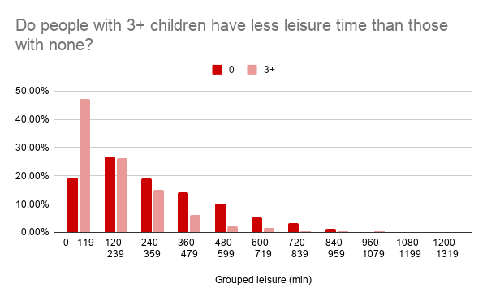

The finished grouped histogram, as percentages of each group.

**WarningGotcha: compare percentages, not counts**

There are 1,137 people with no children and 180 with 3+. In counts, the no-children bars are taller in almost every bin, just because the group is bigger. In percentages, 47% of people with 3+ children report under 2 hours of leisure, against 19% with no children. Counts compare group sizes; percentages compare shapes.

Sheets’ own **Histogram** chart type can draw two groups, but it only counts, so it misleads in exactly this way.

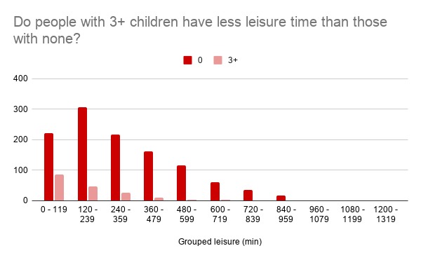

The same chart showing counts (**Show as: Default**). The no-children bars tower over the 3+ bars because that group is six times bigger, which hides how differently the two groups spend their days.

## 8.5 Save your chart

Click the chart’s **⋮** menu > **Download** > **PNG image** or **SVG**. SVG stays sharp at any size, which suits posters and papers.

**TipExtra: box plots, violin plots and error bars**

Sheets doesn’t have these built in. Its error bars can only be one constant, a percentage, or one standard deviation for the whole series, not a separate value for each bar.

| Tool | What it adds |
| --- | --- |
| **Looker Studio** (Google, free) | A built-in box plot chart; reads Google Sheets directly |
| **Google Colab** (Google, free) | Python in the browser. seaborn draws box plots, violin plots and error bars. |
| **Excel** (free to NC State students) | A built-in box and whisker chart, and custom error bars for each bar |
| **R or Python** | Everything, with steps you can repeat |
| **Gemini** (your NC State Google account) | Not built into Sheets for NC State accounts, as of October 2026. Gemini chat can explain a formula, or write Python for Colab to draw these charts. Check what it gives you before you rely on it. |

# 9 Wrapping up

## 9.1 Take your data with you

**File > Download > Comma-separated values (.csv)** saves the current sheet as a CSV, which opens in R, Python, SPSS, Stata and almost everything else. Download **README** too: the data dictionary belongs with the data, and in your own work, so does the log.

## 9.2 What we did

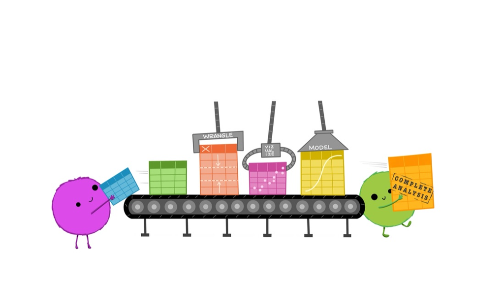

Illustration from [Tidy Data for reproducibility, efficiency, and collaboration](https://openscapes.org/blog/2020-10-12-tidy-data/) by Julia Lowndes and Allison Horst, [CC BY 4.0](https://creativecommons.org/licenses/by/4.0/).

- Kept the raw data untouched and worked on a copy.
- Used the data dictionary to rename, recode and write validation rules.
- Fixed text, spaces, numbers stored as text, missing-value codes, out-of-range values and duplicates.
- Made new variables with formulas.
- Summarized with pivot tables.
- Charted group averages, then the distributions behind them.

And the main lesson: **how you prepare data changes your conclusions.** Write down every decision.

## 9.3 Where to go next

- **R or Python,** when you need steps you can repeat, bigger data, or more statistics.
- **Designing visualizations:** the DSS data visualization workshops, go.ncsu.edu/datavizworkshops.
- **Get Data Help:** go.ncsu.edu/getdatahelp, or getdatahelp@ncsu.edu.
- **Practice:** the extra activities below.

# Extra activities

For fast finishers, and for practice afterwards.

## Recode education levels with a lookup table

The **raw** sheet stores education level as codes 31–46. Recoding 16 codes with Find and replace takes 16 passes, and a lookup table takes one formula.

1. Add a sheet named **lookup**. In A1 and B1 type `Code` and `Label`. In A2:B17, enter codes 31 to 46 and their labels: 31–38 No diploma, 39 High School, 40 Some college-no degree, 41–42 Associate’s, 43 Bachelor’s, 44 Master’s, 45 Professional, 46 Doctoral.
2. Make a copy of the **raw** sheet to practice on (right-click its tab > **Duplicate**). Education level codes are in column E.
3. In a helper column, enter this and fill it down:

   ```
   =XLOOKUP(E2, lookup!$A$2:$A$17, lookup!$B$2:$B$17)
   ```

The lookup table also documents the recode: anyone can see exactly which code became which label.

## One-hot encoding

Some statistical models need a category split into yes/no columns, one per category. For work status: `=IF(AB2="Full time", 1, 0)` in one column, `=IF(AB2="Part time", 1, 0)` in the next, and so on.

## More questions to try

- Does sleep change with the number of children, or with work status?
- Do people in metropolitan and non-metropolitan areas spend their time differently? (Practise concluding “not much difference”.)
- Has leisure time changed from 2003 to 2023? (2020 was a pandemic year.)
- Weekdays vs. weekends: how much does the day of the week matter?
- Are people enrolled in school different?
- What share of chores-plus-leisure time is chores? (Watch out for dividing by zero when both are 0.)

## A strip plot: every person, by group

A strip plot shows one dot per person in each group, nudged sideways at random so dots don’t sit on top of each other, with a marker at each group’s median. You see the spread, the outliers and the center in one chart.

Sheets has no strip plot, so we build one from a scatter chart. The chart data goes on its own sheet, because the median rows sit under the data, which `working` must never have.

**Build the chart data:**

1. Add a sheet named **strip**. In row 1 type the headers: **A1** `Group`, **B1** `x`, **C1** `Leisure (mins)`, **D1** `Group median`.

   A new sheet has only 1,000 rows, and this one needs 2,005. Press **Ctrl/Cmd + ↓** to go to the bottom. Under the last row, in **Add [ ] more rows at the bottom**, type `1005` and click **Add**.
2. Type these formulas in row 2:
   - **A2:** `=MIN(working!H2, 3)`. The number of children, with 3 standing for “3 or more”.
   - **B2:** `=A2 + RAND()*0.6 - 0.3`. The group number, nudged sideways at random.
   - **C2:** `=working!Y2`. Leisure.
3. Fill them down to row 2001: type `A2:C2001` in the **Name box** and press **Enter**, then press **Ctrl/Cmd + D**.
4. With A2:C2001 still selected, copy, then paste values only on top (**Ctrl/Cmd + Shift + V**). `RAND()` picks new numbers every time you edit anything, so without this the dots move around.
5. Add one row for each group’s median, under the data:
   - **A2002:A2005:** `0`, `1`, `2`, `3`.
   - **B2002:** `=A2002`. No nudge, so the median sits in the middle of its group.
   - **D2002:** `=MEDIAN(FILTER(C$2:C$2001, A$2:A$2001 = A2002))`.
   - Select **B2002:D2005** and press **Ctrl/Cmd + D** to fill both formulas down. Column C stays empty in these rows.

Check: the medians are 253, 165, 150 and 120 minutes.

**Make the chart:**

1. Type `B1:D2005` in the Name box and press **Enter**. **Insert > Chart.**
2. **Setup > Chart type: Scatter chart.** Check that the X-axis is `x` and the two series are `Leisure (mins)` and `Group median`.
3. **Customize > Series:**
   - `Leisure (mins)`: **Point size** 2px, **Color** gray, then **Fill opacity** about 20%.
   - `Group median`: **Point size** 14px, **Point shape** Square, and a strong **Color** that stands out from the gray.
4. **Customize > Vertical axis:** min `-30`, so the people with 0 minutes lift off the axis line, and max `1440`.
5. **Customize > Chart & axis titles:** title “Leisure time by number of children”, horizontal axis “Number of children in household (3 = 3 or more)”, vertical axis “Leisure on diary day (minutes)”.
6. Click the chart’s **⋮** menu (top right) > **Alt text**, and describe what it shows.

Things to notice: the medians step down as the number of children rises, and each group has a long upper tail, which is why the median is a better center than the average here. The no-children group is the densest: it has 1,137 people, against 180 with 3+.

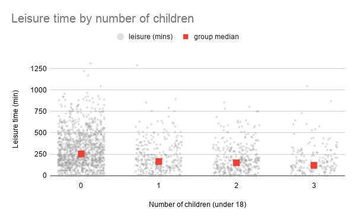

The finished strip plot: one gray dot per person, and a square at each group’s median.

**WarningGotcha: the axis says 3, not 3+**

The horizontal axis is a number line, so its labels are numbers, and the last group reads “3” where it means “3 or more”. Sheets can’t swap an axis number for text, so say it in the axis title, as above. For a figure, you can download the chart as SVG and edit the labels in graphic design software, such as Adobe Illustrator, Canva, Affinity or Inkscape.

# Reference: keyboard shortcuts

Mac users: use **Cmd** where this says **Ctrl**. **Ctrl + /** (the slash key; Mac: **Cmd + /**) shows the full list in Sheets.

| Shortcut | Does |
| --- | --- |
| Ctrl + ↓ (or ↑ ← →) | Jump to the edge of the data |
| Ctrl + Shift + ↓ | Select to the bottom of the data |
| Ctrl + Space | Select the column |
| Shift + Space | Select the row |
| Ctrl + A | Select all |
| Ctrl + C | Copy |
| Ctrl + V | Paste |
| Ctrl + Shift + V | Paste values only |
| Ctrl + D | Fill down |
| Ctrl + Z | Undo |
| Ctrl + F | Find |
| Ctrl + H (Mac: Cmd + Shift + H) | Find and replace |